# day_2

Avery Richards

1/6/2022

```r
library(tidyverse)
library(tidytext)
library(viridis)
```

## Unsupervised methods

In this session, we’ll cover unsupervised computational text analysis approaches. The central methods covered are TF-IDF and Topic Modeling. Both of these are common approachs in the social sciences and humanities.

```r
phy_texts <- read_csv("data/classic_physics_texts.csv")
phy_texts %>% select(text) %>%
  na.omit()
```

```
## # A tibble: 13,247 x 1
##    text
##    <chr>
##  1 EXPERIMENTS WITH ALTERNATE CURRENTS OF HIGH POTENTIAL AND HIGH FREQUENCY
##  2 A Lecture Delivered before the Institution of Electrical Engineers, London
##  3 by
##  4 NIKOLA TESLA
##  5 With a Portrait and Biographical Sketch of the Author
##  6 NEW YORK
##  7 1892
##  8 Biographical Sketch of Nikola Tesla.
##  9 While a large portion of the European family has been surging westward
## 10 during the last three or four hundred years, settling the vast
## # … with 13,237 more rows
```

```r
phy_texts %>%
  group_by(author) %>%
  summarise(lines_per_author = n())
```

```
## # A tibble: 4 x 2
##   author              lines_per_author
##   <chr>                          <int>
## 1 Einstein, Albert                3772
## 2 Galilei, Galileo                4074
## 3 Huygens, Christiaan             3768
## 4 Tesla, Nikola                   3796
```

```r
phy_texts_words <- phy_texts %>%
  select(text, author) %>%
  unnest_tokens(word, text) %>%
  count(author, word, sort = TRUE)

phy_texts_words %>% head(15)
```

```
## # A tibble: 15 x 3
##    author              word      n
##    <chr>               <chr> <int>
##  1 Galilei, Galileo    the    3760
##  2 Tesla, Nikola       the    3604
##  3 Huygens, Christiaan the    3553
##  4 Einstein, Albert    the    2993
##  5 Galilei, Galileo    of     2049
##  6 Einstein, Albert    of     2028
##  7 Tesla, Nikola       of     1737
##  8 Huygens, Christiaan of     1708
##  9 Huygens, Christiaan to     1207
## 10 Tesla, Nikola       a      1176
## 11 Galilei, Galileo    and    1148
## 12 Galilei, Galileo    to     1133
## 13 Galilei, Galileo    that   1104
## 14 Tesla, Nikola       to     1087
## 15 Tesla, Nikola       in      986
```

```r
total_words <- phy_texts_words %>%
  group_by(author) %>%
  summarize(total = sum(n))

phy_texts_words <- left_join(phy_texts_words, total_words)
phy_texts_words
```

```
## # A tibble: 12,675 x 4
##    author              word      n total
##    <chr>               <chr> <int> <int>
##  1 Galilei, Galileo    the    3760 40772
##  2 Tesla, Nikola       the    3604 39819
##  3 Huygens, Christiaan the    3553 38776
##  4 Einstein, Albert    the    2993 32223
##  5 Galilei, Galileo    of     2049 40772
##  6 Einstein, Albert    of     2028 32223
##  7 Tesla, Nikola       of     1737 39819
##  8 Huygens, Christiaan of     1708 38776
##  9 Huygens, Christiaan to     1207 38776
## 10 Tesla, Nikola       a      1176 39819
## # … with 12,665 more rows
```

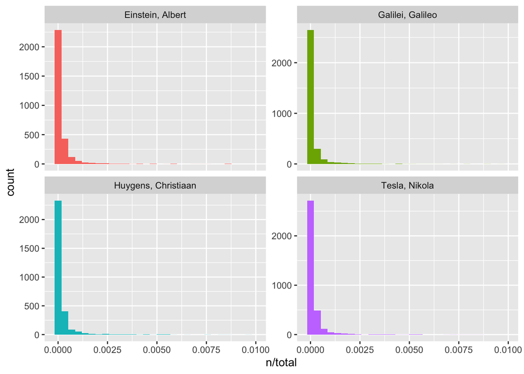

```r
ggplot(phy_texts_words, aes(n/total, fill = author)) +
  geom_histogram(show.legend = FALSE) +
  xlim(NA, 0.01) +
  facet_wrap(~author, ncol = 2, scales = "free_y")
```

```r
phy_texts_tf_idf <- phy_texts_words %>%
  bind_tf_idf(word, author, n) %>%
  mutate(author = factor(author, levels = c("Galilei, Galileo",
                                            "Huygens, Christiaan",
                                            "Tesla, Nikola",
                                            "Einstein, Albert")))

phy_texts_tf_idf %>%
  select(author, word, tf_idf) %>%
    arrange(desc(tf_idf))
```

```
## # A tibble: 12,675 x 3
##    author              word           tf_idf
##    <fct>               <chr>           <dbl>
##  1 Einstein, Albert    relativity    0.00830
##  2 Tesla, Nikola       bulb          0.00595
##  3 Galilei, Galileo    water         0.00584
##  4 Tesla, Nikola       coil          0.00578
##  5 Tesla, Nikola       wire          0.00463
##  6 Galilei, Galileo    hath          0.00449
##  7 Huygens, Christiaan refraction    0.00390
##  8 Einstein, Albert    theory        0.00389
##  9 Einstein, Albert    _k_           0.00374
## 10 Einstein, Albert    gravitational 0.00374
## # … with 12,665 more rows
```

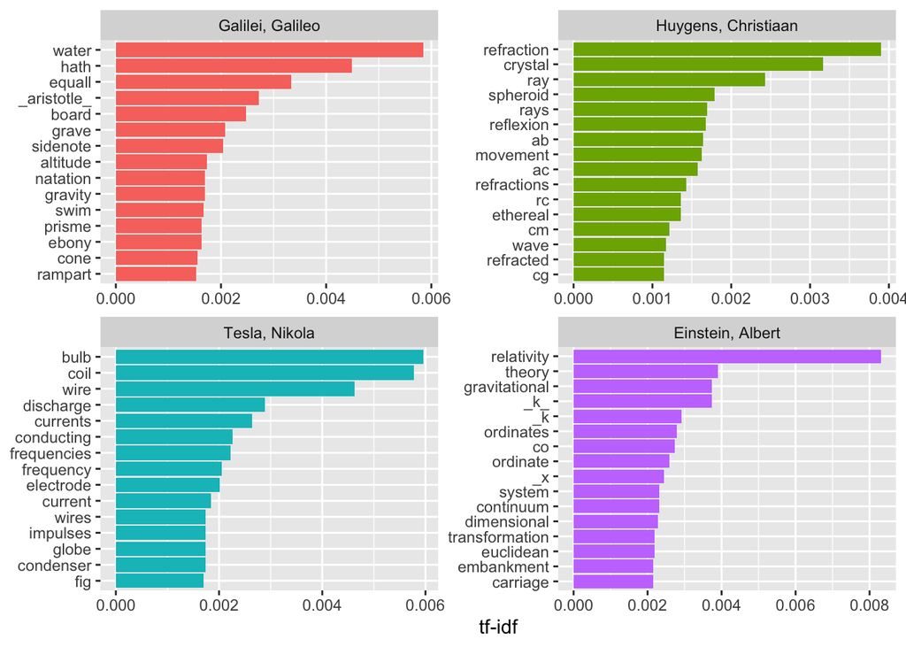

```r
phy_texts_tf_idf  %>%
  group_by(author) %>%
  slice_max(tf_idf, n = 15) %>%
  ungroup() %>%
  mutate(word = reorder(word, tf_idf)) %>%
  ggplot(aes(tf_idf, word, fill = author)) +
  geom_col(show.legend = FALSE) +
  labs(x = "tf-idf", y = NULL) +
  facet_wrap(~author, ncol = 2, scales = "free")
```

Interesting results! There looks to be some noisy terms in our lineup. After digging about we learn that “AB”, “AC”, “RC”, are names of rays, angles,and shapes in Huygens’ writing. We also recognize the terms “co” and “ordinate” right next to each other in Einsteins’ graph. After acknowledging these findings, our next step is to clean up our dataset to make some meaningfull visualizations.

```r
special_stop_words <- tibble(word = c("eq", "co", "rc", "ac", "ak", "bn",
                                   "fig", "file", "cg", "cb", "cm",
                                    "ab", "_k", "_k_", "_x"))

phy_texts_words_clean <- anti_join(phy_texts_words, special_stop_words,
                           by = "word")
```

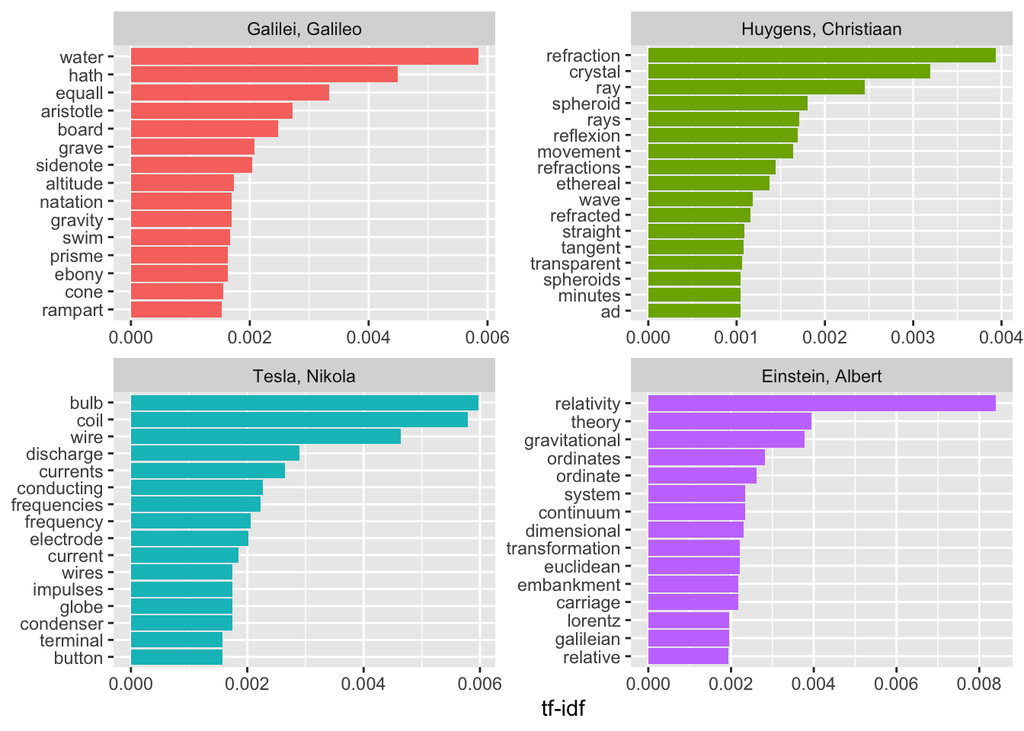

```r
tf_idf_viz <- phy_texts_words_clean  %>%
  bind_tf_idf(word, author, n) %>%
  mutate(word = str_remove_all(word, "_")) %>%
  group_by(author) %>%
  slice_max(tf_idf, n = 15) %>%
  ungroup() %>%
  mutate(word = reorder_within(word, tf_idf, author)) %>%
  mutate(author = factor(author, levels = c("Galilei, Galileo",
                                            "Huygens, Christiaan",
                                            "Tesla, Nikola",
                                            "Einstein, Albert")))

ggplot(tf_idf_viz, aes(word, tf_idf, fill = author)) +
  geom_col(show.legend = FALSE) +
  labs(x = NULL, y = "tf-idf") +
  facet_wrap(~author, ncol = 2, scales = "free") +
  coord_flip() +
  scale_x_reordered()
```

### Topic modeling

The goal of topic models can be twofold:

1/ learning something about the topics themselves, i.e., what the the ext is about 2/ reduce the dimensionality of text to represent a document as a weighted average of K topics instead of a vector of token counts over the whole vocabulary.

In the latter case, topic modeling a way to treat text as any data in a more tractable way for any subsequent statistical analysis (linear/logistic regression, etc).

There are many topic modeling algorithms, but we’ll use LDA. This is a standard model to use. Again, the goal is not to learn everything you need to know about topic modeling. Instead, this will provide you some starter code to run a simple model, with the idea that you can use this base of knowledge to explore this further.

First, a bit of theory. LDA is a generative model - a model over the entire data generating process - in which a document is a mixture of topics and topics are probability distributions over tokens in the vocabulary. The (normalized) frequency of word 𝑗 in document 𝑖 can be written as: 𝑞𝑖𝑗=𝑣𝑖1∗𝜃1𝑗+𝑣𝑖2∗𝜃2𝑗+…+𝑣𝑖𝐾∗𝜃𝐾𝑗 where K is the total number of topics, 𝜃𝑘𝑗 is the probability that word 𝑗 shows up in topic 𝑘 and 𝑣𝑖𝑘 is the weight assigned to topic 𝑘 in document 𝑖. The model treats 𝑣 and 𝜃

as generated from Dirichlet-distributed priors and can be estimated through Maximum Likelihood or Bayesian methods.

The data were compiled by students in this course: http://english197s2015.pbworks.com/w/page/93127947/FrontPage Found here: http://dhresourcesforprojectbuilding.pbworks.com/w/page/69244469/Data%20Collections%20and%20Datasets#demo-corpora

That page has additional corpora, for those interested in exploring text analysis further.

1 Reference: Blei, D. M., A. Y. Ng, and M. I. Jordan (2003). Latent Dirichlet allocation. Journal of Machine Learning Research 3, 993–1022.